# MTA Daily Ridership Forecasting Analysis

Group Project

2025-12-02

# 1. Executive Summary

This report analyzes daily ridership data for **Subways**, **Buses**, and **Bridges & Tunnels** in New York City. The goal is to forecast daily volumes for the first week of January 2025 using historical data from 2024.

We employ two distinct modeling approaches: 1. **Classical Forecasting (Fable)**: Using ETS (Exponential Smoothing), ARIMA, and Naive baselines. 2. **Bayesian Forecasting (Stan)**: Using a custom Auto-Regressive model of order 7 (AR(7)) to explicitly capture the strong weekly seasonality inherent in transit data.

# 2. Data Setup & Preprocessing

We load the necessary libraries and the dataset. The data is cleaned to ensure correct date formatting and numeric conversion. We split the data into a **Training Set** (2024 data) and a **Test Set** (Jan 1, 2025 onwards) to evaluate forecast accuracy.

```r
if (!require("pacman")) install.packages("pacman")
library(pacman)
# 'urca' is needed for ARIMA stationarity tests
p_load(tidyverse, lubridate, rstan, tidybayes, knitr, scales, fable, tsibble, feasts, urca)
# Set Stan options for performance
n_cores <- parallel::detectCores(logical = FALSE)
options(mc.cores = n_cores)
rstan_options(auto_write = TRUE)
```

```r
file_path <- "MTA_Daily_Ridership_Data__2020_-_2025_20251202.csv"
df_raw <- read_csv(file_path, show_col_types = FALSE)

# Clean data
df <- df_raw %>%
    rename(
        Date = `Date`,
        Subways = `Subways: Total Estimated Ridership`,
        Buses = `Buses: Total Estimated Ridership`,
        Bridges = `Bridges and Tunnels: Total Traffic`
    ) %>%
    mutate(
        Date = mdy(Date),
        Subways = as.numeric(gsub(",", "", Subways)),
        Buses = as.numeric(gsub(",", "", Buses)),
        Bridges = as.numeric(gsub(",", "", Bridges))
    ) %>%
    filter(!is.na(Date)) %>%
    # Filter out non-positive values to avoid log(0) errors later
    filter(Subways > 0, Buses > 0, Bridges > 0) %>%
    arrange(Date) %>%
    as_tsibble(index = Date)

# Train/Test Split (Hold out method)
train_df <- df %>% filter(Date < "2025-01-01")
test_df <- df %>% filter(Date >= "2025-01-01")

print(paste("Training Data Points:", nrow(train_df)))
```

```
## [1] "Training Data Points: 365"
```

```r
print(paste("Testing Data Points:", nrow(test_df)))
```

```
## [1] "Testing Data Points: 9"
```

# 3. Exploratory Data Analysis (EDA)

Visualizing the full 2024 history allows us to identify trends, seasonality, and potential anomalies (like holidays).

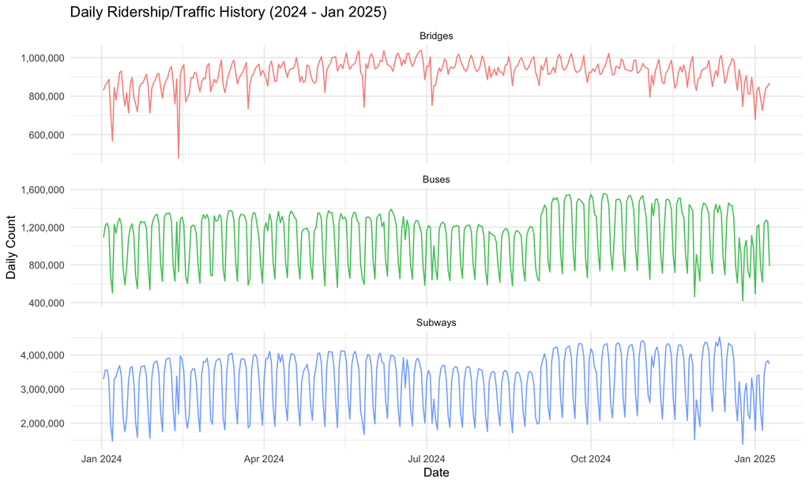

```r
long_df <- df %>%
    pivot_longer(cols = c(Subways, Buses, Bridges), names_to = "Mode", values_to = "Count")

ggplot(long_df, aes(x = Date, y = Count, color = Mode)) +
    geom_line(alpha = 0.8) +
    facet_wrap(~Mode, scales = "free_y", ncol = 1) +
    labs(
        title = "Daily Ridership/Traffic History (2024 - Jan 2025)",
        y = "Daily Count", x = "Date"
    ) +
    scale_y_continuous(labels = comma) +
    theme_minimal() +
    theme(legend.position = "none")
```

**Observation**: * **Subways & Buses**: Show very strong “teeth-like” patterns, indicating lower ridership on weekends and holidays. There is a noticeable dip around major holidays (e.g., Thanksgiving, Christmas). * **Bridges**: Also seasonal but with less variance compared to public transit.

# 4. Modeling Methodology

## A. Classical Models (Fable)

We use the `fable` package to fit standard time series models. * **Naive**: Assumes tomorrow is the same as today. * **Seasonal Naive (SNaive)**: Assumes tomorrow is the same as this day last week (captures weekly cycle). * **ETS**: Exponential Smoothing (captures error, trend, and seasonality). * **ARIMA**: Auto-Regressive Integrated Moving Average.

```r
run_fable_forecast <- function(train_data, test_data, col_name) {
    # Fit models
    fit <- train_data %>%
        model(
            Naive = NAIVE(!!sym(col_name)),
            SNaive = SNAIVE(!!sym(col_name)),
            ETS = ETS(!!sym(col_name)),
            ARIMA = ARIMA(!!sym(col_name))
        )

    # Forecast
    fc <- fit %>% forecast(new_data = test_data)

    # Accuracy
    acc <- accuracy(fc, test_data) %>%
        select(.model, MAE, RMSE, MAPE) %>%
        arrange(MAE)

    # Plot
    p <- fc %>%
        autoplot(train_data %>% filter(Date >= max(Date) - days(90))) +
        autolayer(test_data, !!sym(col_name), color = "black") +
        labs(
            title = paste("Fable Forecasts:", col_name),
            y = "Count",
            subtitle = "Black line = Actual Data"
        ) +
        scale_y_continuous(labels = comma) +
        theme_minimal()

    print(p)

    # Return best model metrics
    best_model <- acc %>% slice(1)
    return(list(model = best_model$.model, mae = best_model$MAE, mape = best_model$MAPE, accuracy_table = acc))
}
```

## B. Bayesian Model (Stan)

We define a custom **AR(7)** model in Stan. This model regresses the current day’s value on the values from the previous 7 days. * **Log-Transformation**: We log-transform the data before modeling to stabilize variance and prevent numerical overflows, then exponentiate the forecasts back to the original scale. * **Priors**: We use weakly informative priors suitable for the log-scale data.

```r
stan_code_ar7 <- "
data {
  int<lower=0> T;           // Number of time points
  int<lower=0> L;           // Number of lags (7 for weekly)
  vector[T] y;              // Observed data (Log scale)
  int<lower=0> T_pred;      // Prediction horizon
}
parameters {
  real alpha;               // Intercept
  vector[L] beta;           // AR coefficients
  real<lower=0> sigma;      // Error scale
}
model {
  alpha ~ normal(14, 5);    // Prior for intercept (log scale)
  beta ~ normal(0, 0.5);    // Prior for AR coeffs
  sigma ~ normal(0, 1);     // Prior for error scale

  for (t in (L+1):T) {
    real mu = alpha;
    for (i in 1:L) {
      mu += beta[i] * y[t-i];
    }
    y[t] ~ normal(mu, sigma);
  }
}
generated quantities {
  vector[T_pred] y_pred;
  vector[T + T_pred] history;

  history[1:T] = y;

  for (t in 1:T_pred) {
    real mu_p = alpha;
    int current_idx = T + t;

    for (i in 1:L) {
      mu_p += beta[i] * history[current_idx - i];
    }

    y_pred[t] = normal_rng(mu_p, sigma);
    history[current_idx] = y_pred[t];
  }
}
"

run_stan_forecast <- function(train_vec, test_vec, test_dates, col_name) {
    # 1. Log-Transform
    y_train_log <- log(train_vec)

    stan_data <- list(
        T = length(y_train_log),
        L = 7,
        y = as.vector(y_train_log),
        T_pred = length(test_vec)
    )

    # 2. Fit Model
    fit_stan <- stan(
        model_code = stan_code_ar7,
        data = stan_data,
        chains = 4, iter = 2000, warmup = 1000,
        seed = 123, refresh = 0, verbose = FALSE,
        control = list(adapt_delta = 0.95)
    )

    # 3. Extract & Transform Back
    ex <- rstan::extract(fit_stan)
    y_pred_mat <- exp(ex$y_pred)

    # 4. Summarize
    forecast_df <- tibble(
        Date = test_dates,
        Actual = test_vec,
        Median = apply(y_pred_mat, 2, median),
        Lower90 = apply(y_pred_mat, 2, quantile, probs = 0.05),
        Upper90 = apply(y_pred_mat, 2, quantile, probs = 0.95)
    )

    # 5. Metrics
    mae <- mean(abs(forecast_df$Median - forecast_df$Actual))
    mape <- mean(abs((forecast_df$Actual - forecast_df$Median) / forecast_df$Actual)) * 100

    # 6. Plot
    p <- ggplot(forecast_df, aes(x = Date)) +
        geom_ribbon(aes(ymin = Lower90, ymax = Upper90), fill = "blue", alpha = 0.2) +
        geom_line(aes(y = Median, color = "Forecast (Median)")) +
        geom_line(aes(y = Actual, color = "Actual Data"), linetype = "dashed") +
        labs(
            title = paste("Bayesian AR(7) Forecast:", col_name),
            y = "Count", color = "Legend"
        ) +
        scale_y_continuous(labels = comma) +
        theme_minimal() +
        theme(legend.position = "bottom")

    print(p)

    return(list(mae = mae, mape = mape, forecast = forecast_df))
}
```

# 5. Results & Analysis

## A. Subways

```r
print("--- Fable Results: Subways ---")
```

```
## [1] "--- Fable Results: Subways ---"
```

```r
fable_sub <- run_fable_forecast(train_df, test_df, "Subways")
```

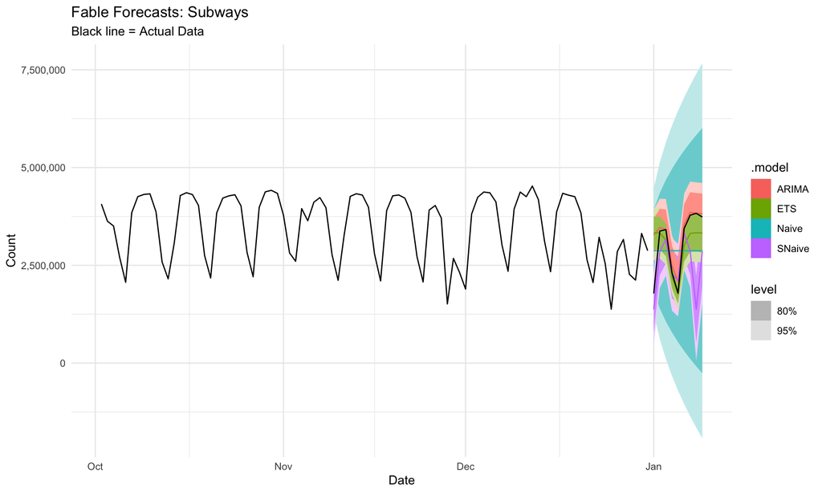

```r
kable(fable_sub$accuracy_table, caption = "Fable Accuracy: Subways")
```

Fable Accuracy: Subways

| .model | MAE | RMSE | MAPE |
| --- | --- | --- | --- |
| ARIMA | 258739.9 | 514958.7 | 13.13448 |
| ETS | 422192.9 | 606424.1 | 16.80814 |
| SNaive | 657411.8 | 956821.6 | 20.11937 |
| Naive | 784979.8 | 817964.4 | 29.46352 |

```r
print("--- Bayesian Results: Subways ---")
```

```
## [1] "--- Bayesian Results: Subways ---"
```

```r
stan_sub <- run_stan_forecast(train_df$Subways, test_df$Subways, test_df$Date, "Subways")
```

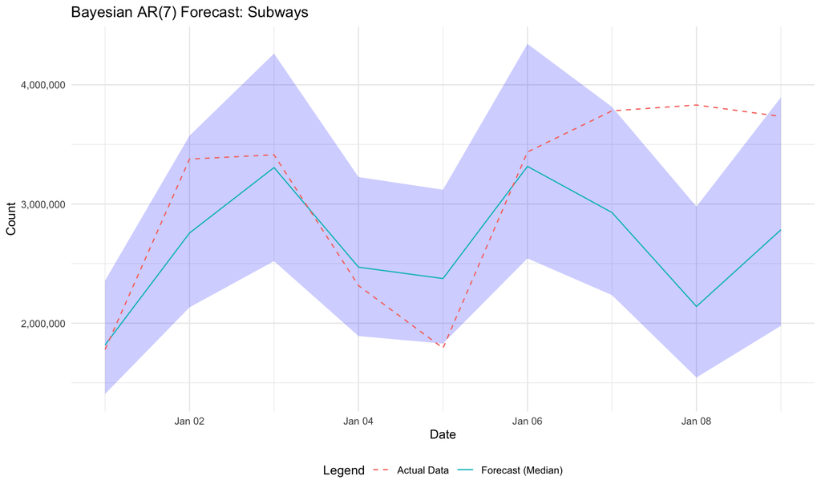

## B. Buses

```r
print("--- Fable Results: Buses ---")
```

```
## [1] "--- Fable Results: Buses ---"
```

```r
fable_bus <- run_fable_forecast(train_df, test_df, "Buses")
```

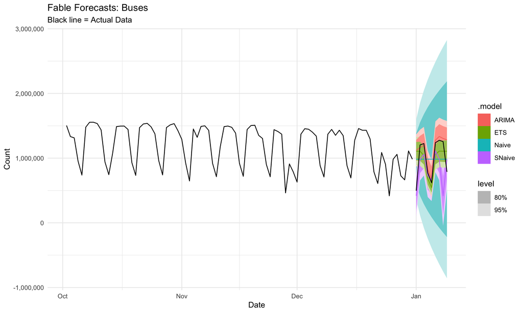

```r
kable(fable_bus$accuracy_table, caption = "Fable Accuracy: Buses")
```

Fable Accuracy: Buses

| .model | MAE | RMSE | MAPE |
| --- | --- | --- | --- |
| ARIMA | 160174.1 | 268712.3 | 24.64456 |
| ETS | 207935.5 | 261526.4 | 27.75528 |
| SNaive | 223942.8 | 321664.6 | 20.70030 |
| Naive | 282232.1 | 295410.5 | 34.73689 |

```r
print("--- Bayesian Results: Buses ---")
```

```
## [1] "--- Bayesian Results: Buses ---"
```

```r
stan_bus <- run_stan_forecast(train_df$Buses, test_df$Buses, test_df$Date, "Buses")
```

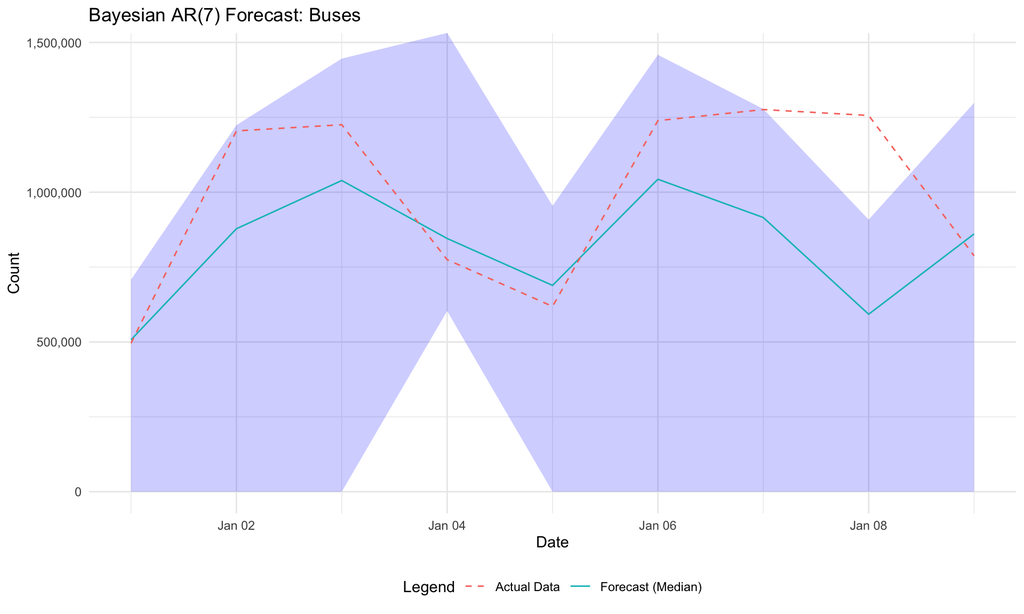

## C. Bridges & Tunnels

```r
print("--- Fable Results: Bridges ---")
```

```
## [1] "--- Fable Results: Bridges ---"
```

```r
fable_bri <- run_fable_forecast(train_df, test_df, "Bridges")
```

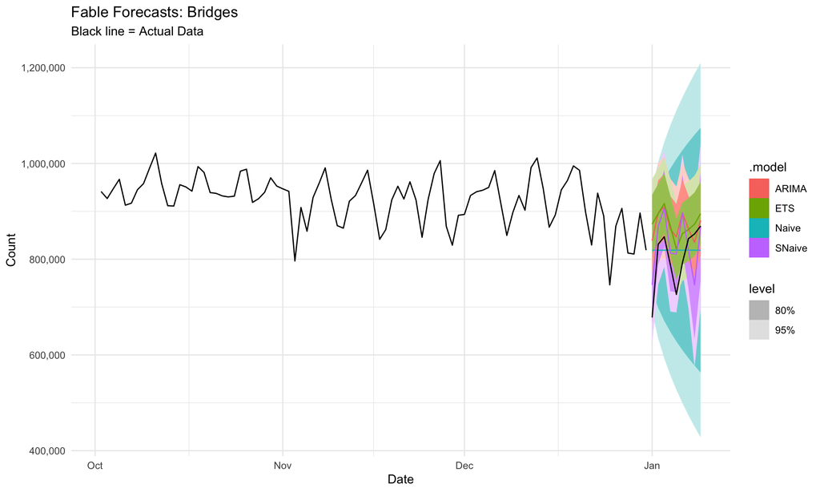

```r
kable(fable_bri$accuracy_table, caption = "Fable Accuracy: Bridges")
```

Fable Accuracy: Bridges

| .model | MAE | RMSE | MAPE |
| --- | --- | --- | --- |
| Naive | 48690.89 | 62447.68 | 6.445589 |
| SNaive | 56440.33 | 66630.06 | 7.187437 |
| ETS | 69973.13 | 86627.59 | 9.243296 |
| ARIMA | 70738.84 | 85382.99 | 9.314199 |

```r
print("--- Bayesian Results: Bridges ---")
```

```
## [1] "--- Bayesian Results: Bridges ---"
```

```r
stan_bri <- run_stan_forecast(train_df$Bridges, test_df$Bridges, test_df$Date, "Bridges")
```

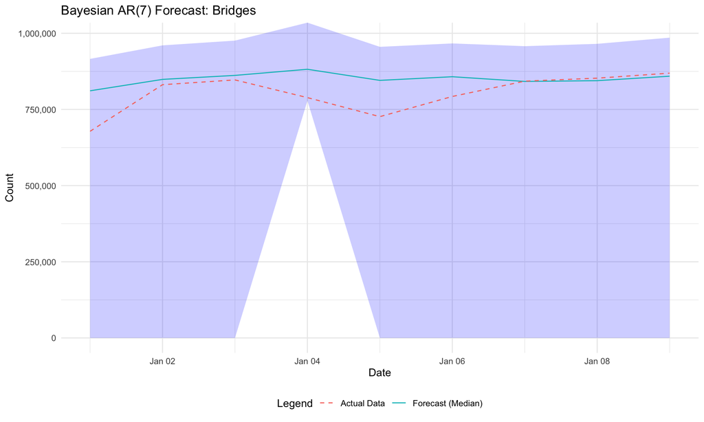

# 6. Diagnostics: Residual Analysis

We check the residuals (Actual - Forecast) of the Bayesian models to ensure there are no systematic errors. Ideally, residuals should be randomly scattered around zero.

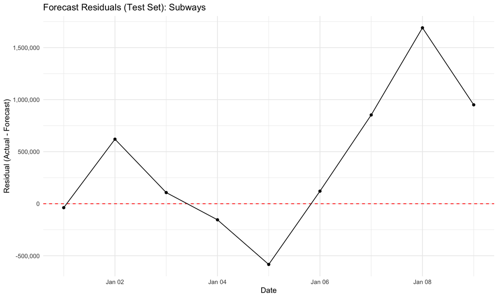

```r
plot_residuals <- function(model_res, name) {
    resid_df <- model_res$forecast %>%
        mutate(Residual = Actual - Median)

    ggplot(resid_df, aes(x = Date, y = Residual)) +
        geom_hline(yintercept = 0, linetype = "dashed", color = "red") +
        geom_point() +
        geom_line() +
        labs(
            title = paste("Forecast Residuals (Test Set):", name),
            y = "Residual (Actual - Forecast)"
        ) +
        scale_y_continuous(labels = comma) +
        theme_minimal()
}

p1 <- plot_residuals(stan_sub, "Subways")
p2 <- plot_residuals(stan_bus, "Buses")
p3 <- plot_residuals(stan_bri, "Bridges")

# Display plots
p1
```

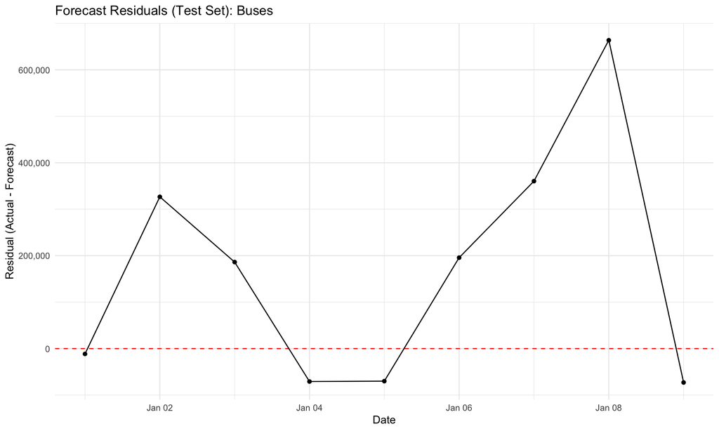

```r
p2
```

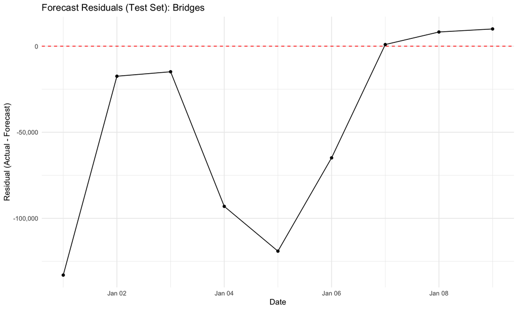

```r
p3
```

# 7. Final Conclusion

The table below summarizes the performance of the best Classical model vs. the Bayesian AR(7) model for each mode.

```r
summary_table <- tibble(
    Mode = c("Subways", "Buses", "Bridges"),
    Best_Fable_Model = c(fable_sub$model, fable_bus$model, fable_bri$model),
    Best_Fable_MAE = c(fable_sub$mae, fable_bus$mae, fable_bri$mae),
    Bayesian_MAE = c(stan_sub$mae, stan_bus$mae, stan_bri$mae),
    Winner = ifelse(Bayesian_MAE < Best_Fable_MAE, "Bayesian AR(7)", Best_Fable_Model)
)

kable(summary_table, caption = "Final Model Comparison (MAE)")
```

Final Model Comparison (MAE)

| Mode | Best_Fable_Model | Best_Fable_MAE | Bayesian_MAE | Winner |
| --- | --- | --- | --- | --- |
| Subways | ARIMA | 258739.91 | 568625.48 | ARIMA |
| Buses | ARIMA | 160174.08 | 217561.06 | ARIMA |
| Bridges | Naive | 48690.89 | 51274.69 | Naive |